# Covid91 vaccine study Final2021

# 7 Results

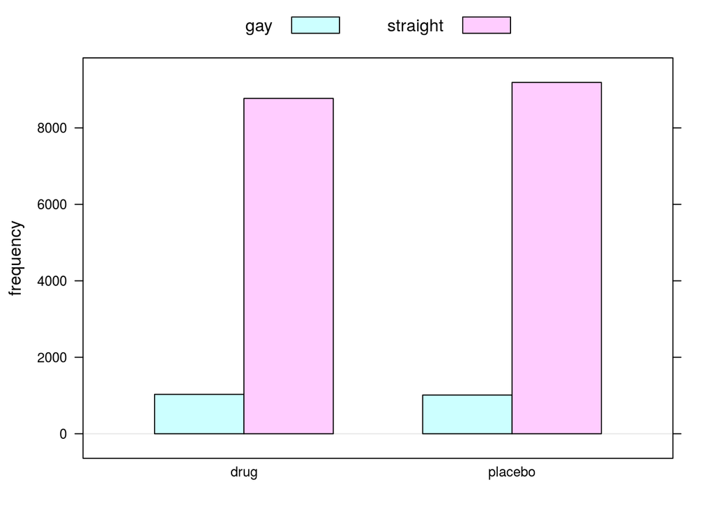

```r
barchartGC(~treatment + LGBTQ,data=FinalData)
```

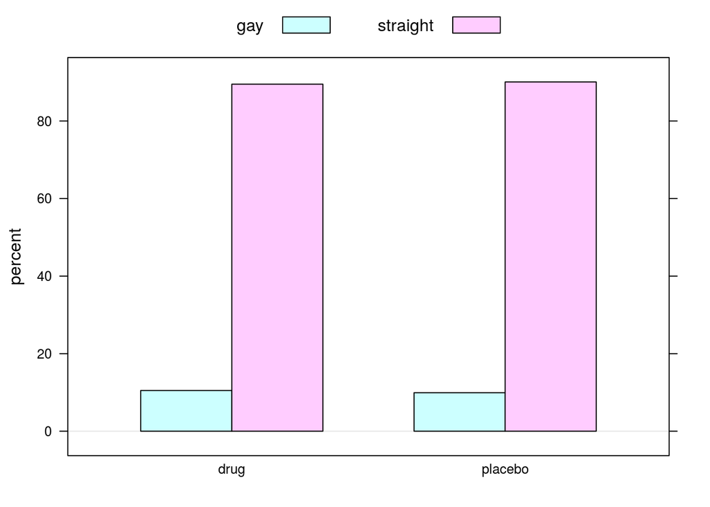

```r
barchartGC(~treatment + LGBTQ,data=FinalData, type="percent")
```

# 8 Numericial Results

```r
table1 <- xtabs(~treatment + LGBTQ, data=FinalData)
rowPerc(table1)
```

```
##          LGBTQ
## treatment    gay straight  Total
##   drug     10.50    89.50 100.00
##   placebo   9.93    90.07 100.00
```

```r
colPerc(table1)
```

```
##          LGBTQ
## treatment    gay straight
##   drug     50.39    48.84
##   placebo  49.61    51.16
##   Total   100.00   100.00
```

# 9 Inferential Results

```r
chisq.test(table1)
```

```
##
##  Pearson's Chi-squared test with Yates' continuity correction
##
## data:  table1
## X-squared = 1.7138, df = 1, p-value = 0.1905
```

```r
chisqtestGC(table1)
```

```
## Pearson's Chi-squared test with Yates' continuity correction
##
## Observed Counts:
##          LGBTQ
## treatment  gay straight
##   drug    1029     8770
##   placebo 1013     9188
##
## Counts Expected by Null:
##          LGBTQ
## treatment     gay straight
##   drug    1000.48  8798.52
##   placebo 1041.52  9159.48
##
## Contributions to the chi-square statistic:
##          LGBTQ
## treatment  gay straight
##   drug    0.81     0.09
##   placebo 0.78     0.09
##
##
## Chi-Square Statistic = 1.7138
## Degrees of Freedom of the table = 1
## P-Value = 0.1905
```

```r
fisher.test(table1)
```

```
##
##  Fisher's Exact Test for Count Data
##
## data:  table1
## p-value = 0.1831
## alternative hypothesis: true odds ratio is not equal to 1
## 95 percent confidence interval:
##  0.9700585 1.1675433
## sample estimates:
## odds ratio
##   1.064173
```

# 10 Discussion and Conclusion

In this discussion we wanted to analyze the effectiveness of the covid 19 treatment across different subpopulations, that is consist of drug user, sexes and sexual denominations. According to the p-value in each break down in the different subgroups the margin of difference was so small we where unable to conclude a definite hypotheses that the effectiveness of the treatment on each group. Therefore,there is no difference between the subgroups in accordance to the effectiveness of the preventative covid19 vaccine.